# Mass Tests Condensed

## 5.5 2a and 2b Combined Utility fits

This section analysis fits one $\alpha$ value to experiment 2a and 2b at the same time. These next tables show the movement durations, predicted movement durations, the fitted alpha values, and the probabilities of success. The $\alpha$ value for 2a and 2b are fit at once, so it is the same. 2c has its own $\alpha$ value.

The $\alpha$ value fitted here is 40.1149594. The SSE for experiment 2a/2b when using one alpha is 1.201e-03. The SSE for experiment 2c is 9.692e-04. The total SSE for all 3 is 2.170e-03.

Table 5.9: Experimental and predicted movement durations for the experiments.

|  | 2a Exp | 2a pred | 2b Exp | 2b pred | 2c Exp | 2c pred |
| --- | --- | --- | --- | --- | --- | --- |
| 2.47 | 0.7638165 | 0.779 | 0.8226259 | 0.810 | 0.6316043 | 0.658 |
| 3.8 | 0.8299896 | 0.837 | 0.8812989 | 0.870 | 0.7032684 | 0.708 |
| 4.7 | 0.8559532 | 0.867 | 0.9051184 | 0.902 | 0.7412180 | 0.734 |
| 6.1 | 0.8902248 | 0.905 | 0.9588485 | 0.942 | 0.7810693 | 0.767 |

Table 5.10: Probabilites of success for the experiments.

|  | 2a | 2b | 2c |
| --- | --- | --- | --- |
| 2.47 | 0.9791 | 0.8235 | 1 |
| 3.8 | 0.9810 | 0.8272 | 1 |
| 4.7 | 0.9819 | 0.8291 | 1 |
| 6.1 | 0.9829 | 0.8315 | 1 |

Table 5.11: Alpha values fitted to experiment 2a/2b, and a seperate alpha for 2c.

|  | 2a | 2b | 2c |
| --- | --- | --- | --- |
| lpha | 40.115 | 40.115 | 95.665 |

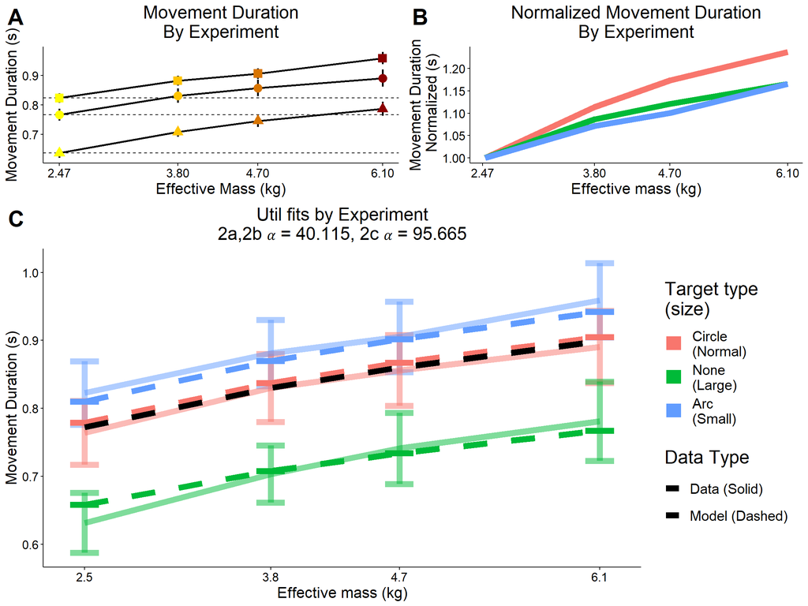

Figure 5.2: Utility fits across experiments.

## 5.6 2a Durations

### 5.6.1 MOdel Plotting Function

### 5.6.2 DF Creation

### 5.6.3 Peak Velocity Plotting

### 5.6.4 SSE of models - Exp 2a

The utility combined alpha is using the alpha value predicted off fitting a utility model to the preferred and small target experiement at the same time. This alpha value is used to make figure 5.2.

#### 5.6.4.1 Absolute

This table shows the SSE for the 2a movement duration and peak velocity predictions.

Table 5.12: Exp 2a - Sum squared errors for movement duration and peak velocity.

|  | Model | Movement Duration SSE | Movement Duration AIC | Movement Duration BIC | Peak Velocity SSE | Peak Velocity AIC | Peak Velocity BIC |
| --- | --- | --- | --- | --- | --- | --- | --- |
| SSE.2 | Accuracy Prob | 3.867e-03 | -2.58e+01 | -2.64e+01 | 7.421e-04 | -3.24e+01 | -3.30e+01 |
| SSE.3 | Met Cost Gross | 6.272e-02 | -1.46e+01 | -1.52e+01 | 3.904e-03 | -2.57e+01 | -2.63e+01 |
| SSE.4 | Met Cost Net | 2.695e-02 | -1.80e+01 | -1.86e+01 | 3.711e-03 | -2.59e+01 | -2.65e+01 |
| SSE.5 | Torque^2 | 1.177e-01 | -1.21e+01 | -1.27e+01 | 1.641e-02 | -2.00e+01 | -2.06e+01 |
| SSE.7 | Utility Gross | 4.200e-05 | -4.19e+01 | -4.31e+01 | 4.580e-04 | -3.23e+01 | -3.35e+01 |
| SSE.9 | Utility Net | 5.874e-05 | -4.05e+01 | -4.17e+01 | 4.647e-04 | -3.22e+01 | -3.35e+01 |
| SSE.10 | Utility Gross Combined Alpha | 6.200e-04 | -3.11e+01 | -3.23e+01 | 7.443e-04 | -3.04e+01 | -3.16e+01 |
| SSE.11 | Utility Net Combined Alpha | 6.668e-05 | -4.00e+01 | -4.12e+01 | 4.246e-04 | -3.26e+01 | -3.38e+01 |

#### 5.6.4.2 Normalized

Table 5.13: Exp 2a - Sum squared errors for NORMALIZED movement duration and peak velocity.

|  | Model | Movement Duration SSE | Movement Duration AIC | Movement Duration BIC | Peak Velocity SSE | Peak Velocity AIC | Peak Velocity BIC |
| --- | --- | --- | --- | --- | --- | --- | --- |
| SSE.2 | Accuracy Prob | 1.683e-02 | -1.99e+01 | -2.05e+01 | 3.270e-02 | -1.72e+01 | -1.78e+01 |
| SSE.3 | Met Cost Gross | 1.914e-03 | -2.86e+01 | -2.92e+01 | 1.153e-02 | -2.14e+01 | -2.20e+01 |
| SSE.4 | Met Cost Net | 2.137e-03 | -2.81e+01 | -2.88e+01 | 1.197e-02 | -2.12e+01 | -2.19e+01 |
| SSE.5 | Torque^2 | 1.425e+00 | -2.13e+00 | -2.74e+00 | 2.234e-01 | -9.54e+00 | -1.02e+01 |
| SSE.7 | Utility Gross | 1.795e-04 | -3.60e+01 | -3.73e+01 | 6.631e-03 | -2.16e+01 | -2.28e+01 |
| SSE.9 | Utility Net | 1.580e-04 | -3.66e+01 | -3.78e+01 | 6.235e-03 | -2.19e+01 | -2.31e+01 |
| SSE.10 | Utility Gross Combined Alpha | 2.211e-04 | -3.52e+01 | -3.64e+01 | 6.845e-03 | -2.15e+01 | -2.27e+01 |
| SSE.11 | Utility Net Combined Alpha | 1.517e-04 | -3.67e+01 | -3.79e+01 | 6.167e-03 | -2.19e+01 | -2.31e+01 |

### 5.6.5 2a Modeling Plot

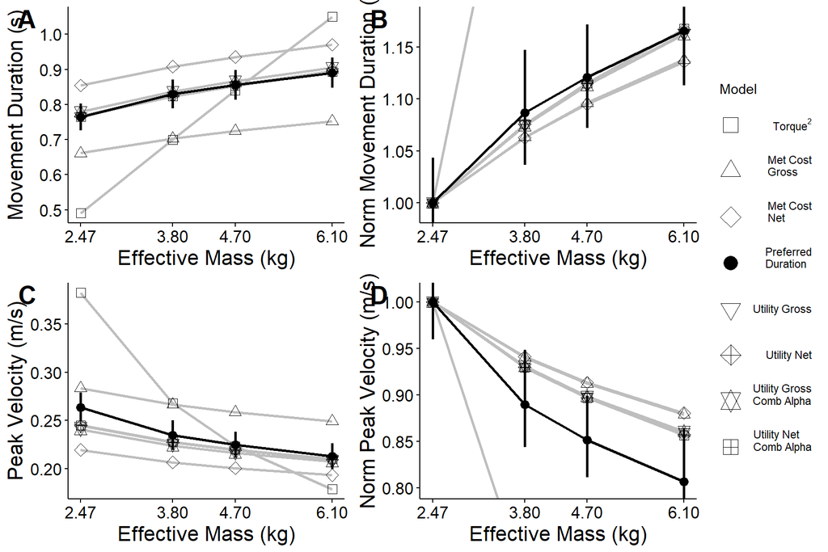

Figure 5.3: Modeling Results